# visa11

IMPORTING LIBRARIES

```python
import numpy as np
import re
import seaborn as sns
import matplotlib.pyplot as plt
%matplotlib inline
from textblob import TextBlob
from nltk.tokenize import word_tokenize
from nltk.stem import WordNetLemmatizer
from nltk.corpus import stopwords
stop_words = set(stopwords.words('english'))
from wordcloud import WordCloud
from nltk import wordnet
from sklearn.feature_extraction.text import CountVectorizer
from sklearn.model_selection import train_test_split
from sklearn.linear_model import LogisticRegression
from sklearn.metrics import accuracy_score, classification_report, confusion_matrix, ConfusionMatrixDisplay
```

```python
import pandas as pd
Data= pd.read_csv("C:\\Users\\Eashan M Shetty\\Desktop\\ALOK\\security11.csv")
```

```python
import nltk
nltk.download('wordnet')
```

```
False
```

```python
lemmatizer = WordNetLemmatizer()
def lemmatize(data):
    text = [lemmatizer.lemmatize(word) for word in data]
    return data


Data['full_text'] = Data['full_text'].apply(lambda x: lemmatize(x))
```

```python
#ASSIGNING THE POLARITY

def polarity(text):
    return TextBlob(text).polarity
Data['polarity'] = Data['full_text'].apply(polarity)
def sentiment(label):
    if label<0:
        return "Negetive"
    elif label == 0:
        return "Neutral"
    elif label>0:
        return "Positive"
Data['Sentiment'] = Data['polarity'].apply(sentiment)
Data.head(20)
```

|  | Unnamed: 0 | full_text | polarity | Sentiment |
| --- | --- | --- | --- | --- |
| 0 | 0 | recently scammed airasia bangalore airport in... | -1.333333e-01 | Negetive |
| 1 | 1 | canada leverage 5 eyes country lot prime real... | 2.000000e-01 | Positive |
| 2 | 2 | coral card visa platinum international card a... | 0.000000e+00 | Neutral |
| 3 | 3 | many many passengers facing inconvenience ch... | 5.000000e-01 | Positive |
| 4 | 4 | good experience flights bad experience airvist... | 5.551115e-17 | Positive |
| 5 | 5 | good experience flights bad experience airvist... | 5.551115e-17 | Positive |
| 6 | 7 | travelling choice difficult days visas easy t... | 2.472222e-01 | Positive |
| 7 | 8 | access lounge bangalore airport using hsbc vi... | 3.000000e-01 | Positive |
| 8 | 9 | sir bad experience bangalore airport morning f... | -1.500000e-01 | Negetive |
| 9 | 10 | blrairport bizarre rulelots issues visasfligh... | 4.000000e-01 | Positive |
| 10 | 11 | worst pathetic service bangalore airport allo... | -8.333333e-01 | Negetive |
| 11 | 12 | worst pathetic service bangalore airport allo... | -8.333333e-01 | Negetive |
| 12 | 13 | sorry figure mumbai bangalore airport lounges... | -5.000000e-01 | Negetive |
| 13 | 14 | bangalore airport staff needs educated schenge... | 0.000000e+00 | Neutral |
| 14 | 15 | went checkin security visa check 35 minutes ba... | -4.000000e-01 | Negetive |
| 15 | 16 | office stuck bangalore airport visa issue anyw... | 0.000000e+00 | Neutral |
| 16 | 17 | cryptovegetor blrairport yeah cousin denied fr... | 4.000000e-01 | Positive |
| 17 | 18 | waiting bangalore airport domestic longue sta... | 0.000000e+00 | Neutral |
| 18 | 19 | well ba staff bangalore airport following ukg... | 0.000000e+00 | Neutral |
| 19 | 20 | respected honourable minister iam travelling ... | 0.000000e+00 | Neutral |

```python
#DROPING THE UNWANTED COLUMNS
Data.drop(columns=['Unnamed: 0','polarity'], axis=1)
```

|  | full_text | Sentiment |
| --- | --- | --- |
| 0 | recently scammed airasia bangalore airport in... | Negetive |
| 1 | canada leverage 5 eyes country lot prime real... | Positive |
| 2 | coral card visa platinum international card a... | Neutral |
| 3 | many many passengers facing inconvenience ch... | Positive |
| 4 | good experience flights bad experience airvist... | Positive |
| ... | ... | ... |
| 69 | bangalore visa arrival foreigners bangalore ai... | Negetive |
| 70 | visa arrival foreigners bangalore airport | Neutral |
| 71 | toibangalore visa arrival foreigners bangalore... | Neutral |
| 72 | visa arrival foreigners bangalore airport | Neutral |
| 73 | toibangalore visa arrival foreigners bangalore... | Neutral |

74 rows × 2 columns

```python
Data.to_csv('security14.csv')
```

```python
import pandas as pd
from sklearn.feature_extraction.text import CountVectorizer
from sklearn.decomposition import LatentDirichletAllocation
from sklearn.feature_extraction import text
import matplotlib.pyplot as plt
from wordcloud import WordCloud
```

```python
hData= pd.read_csv("C:\\Users\\Eashan M Shetty\\Desktop\\ALOK\\security12.csv")
```

```python
hData = hData.drop(hData.columns[hData.columns.str.contains('Unnamed', case=False)], axis=1)
```

```python
hData.Sentiment.value_counts()
```

```
Positive    12
Neutral     11
Negetive     8
Name: Sentiment, dtype: int64
```

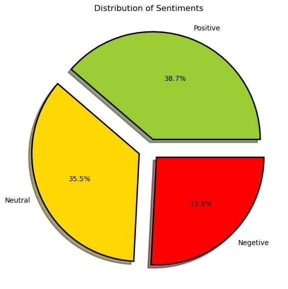

```python
# Pie-Chart
fig = plt.figure(figsize=(7,7))
colors = ("yellowgreen", "gold", "red")
wp={'linewidth':2, 'edgecolor':"black"}
tags = hData['Sentiment'].value_counts()
explode = (0.1, 0.1, 0.1)
tags.plot(kind='pie', shadow=True, colors=colors, autopct='%1.1f%%', wedgeprops=wp, explode=explode, label='')
plt.title("Distribution of Sentiments")
```

# Collecting all the Negetive Tweets from the dataset

```python
negetive_tweets = hData[hData.Sentiment == 'Negetive']

negetive_reviwes = negetive_tweets['Tweets'].tolist()
```

```python
custom_stop_words = ["checkin", "service", "arrived", "among", "terminal", "international", "apparently", "for", "comfortable"]
```

```python
stop_words = text.ENGLISH_STOP_WORDS.union(custom_stop_words)
```

```python
# Weightage of the words in the tweets
stop_words = [frozenset(stop_words)]
vectorizer = CountVectorizer(max_df = 0.95, min_df = 2, stop_words = stop_words)
x = vectorizer.fit_transform(negetive_reviwes)
# Lda model
num_topics = 6
lda = LatentDirichletAllocation(n_components = num_topics, random_state=1)
lda.fit(x)
```

```
LatentDirichletAllocation(n_components=6, random_state=1)
```

```python
num_top_words = 7
feature_names = vectorizer.get_feature_names_out()
topics=[]
```

```python
# Extracting the topics from LDA model
for topic_idx, topic in enumerate(lda.components_):
    top_words_idx = topic.argsort()[:-num_top_words - 1:-1]
    top_words = [feature_names[i] for i in top_words_idx]
    topics.append(top_words)

for i, topic in enumerate(topics):
    print(f"Topic {i+1}: {',' .join(topic)}")
```

```
Topic 1: security,airport,really,bottles,slow,checking,remove
Topic 2: airport,security,slow,remove,items,bottles,checking
Topic 3: airport,security,slow,bottles,checking,really,remove
Topic 4: airport,security,slow,bottles,checking,really,remove
Topic 5: security,remove,items,airport,checking,slow,bottles
Topic 6: airport,security,slow,bottles,checking,really,remove
```

# WordCloud

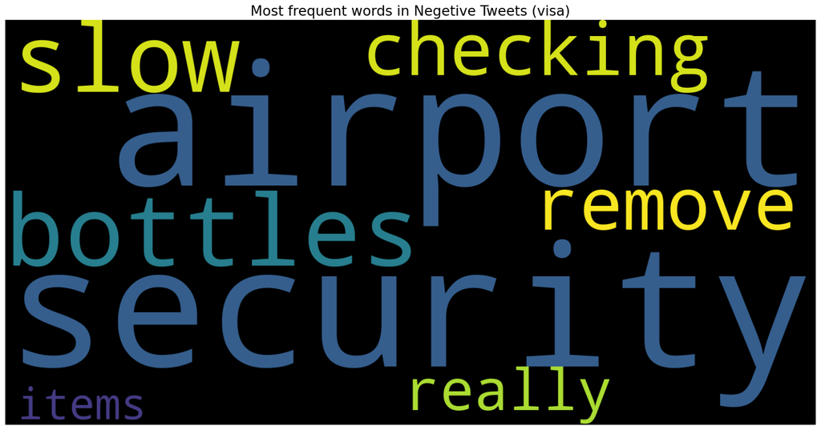

```python
res = [' '.join(ele) for ele in topics]
text = ' '.join([word for word in res])
plt.figure(figsize=(20,15), facecolor='None')
wordcloud= WordCloud(max_words=500, width=1600, height=800).generate(text)
plt.imshow(wordcloud, interpolation='bilinear')
plt.axis("off")
plt.title('Most frequent words in Negetive Tweets (visa)', fontsize=19)
plt.show()
```

**Observation for negative tweets:**

3) Poor Management services:

• By poor visa check and management service the immigration process can be slowed down and this can happen when there is lack of coordination at the airport.

```python
# Collecting all the Positive Tweets from the dataset
```

```python
positive_tweets = hData[hData.Sentiment == 'Positive']

positive_reviews = positive_tweets['Tweets'].tolist()
```

```python
# Weightage of the words in the tweets
vectorizer = CountVectorizer(max_df = 0.95, min_df = 2, stop_words = stop_words)
x = vectorizer.fit_transform(positive_reviews)
```

```python
# Lda model
num_topics = 6
lda = LatentDirichletAllocation(n_components = num_topics, random_state=1)
lda.fit(x)
```

```
LatentDirichletAllocation(n_components=6, random_state=1)
```

```python
num_top_words = 7
feature_names = vectorizer.get_feature_names_out()
topics=[]
```

```python
# Extracting the topics from LDA model
for topic_idx, topic in enumerate(lda.components_):
    top_words_idx = topic.argsort()[:-num_top_words - 1:-1]
    top_words = [feature_names[i] for i in top_words_idx]
    topics.append(top_words)

for i, topic in enumerate(topics):
    print(f"Topic {i+1}: {',' .join(topic)}")
```

```
Topic 1: visa,please,access,lounge,kindly,us,indians
Topic 2: india,visas,visa,arrival,meaindia,flight,get
Topic 3: visa,free,entry,new,year,denied,student
Topic 4: checkin,staff,experience,counter,flights,visa,counters
Topic 5: visas,available,days,flights,tickets,blrairport,arrival
Topic 6: visa,arrival,help,customs,know,immigration,meaindia
```

# WordCloud

[figure not shown]

```python
res = [' '.join(ele) for ele in topics]
text = ' '.join([word for word in res])
plt.figure(figsize=(20,15), facecolor='None')
wordcloud= WordCloud(max_words=500, width=1600, height=800).generate(text)
plt.imshow(wordcloud, interpolation='bilinear')
plt.axis("off")
plt.title('Most frequent words in Positive Tweets(visa)', fontsize=19)
plt.show()
```

**Observation for positive tweets:**

1) Improved visa Process and easy access:

• The security process at Bangalore Airport was smooth and hassle-free which allowed passengers to complete the procedure quickly and without any unnecessary delays. • The bangalore airport had a very easy to access environment which helps in the immigration sector. .

2) Convenient location and accessibility: • The convenient location of the Red Key Airport Hotel on Kempegowda International Airport Road was mentioned which offered budget-friendly accommodation and welcoming hospitality for guests.

3) Enhanced Technologies and developments:

• There are continuous efforts to develop and help the immigrats and the service is done in the efficient way.The airport has used modern technology which includes the DigiYatra system, to streamline and simplify the security process.